# Article Popularity Prediction.

## Problem

Article popularity is one of key aspects of the online content.The more the shares the more it will be popular.Predicting the shares will be very usefull for the online content companies because they will know which sort of artilces are getting more shares,what type of artilces are getting more shares by knowing these insights the company can find ways to improve their content and attract more people to go through their contents.

## Dataset

The Dataset is collected from mashable a global multi-platform media and entertainment company.The data is collected over the period of few years and mashable has collected data on around 40,000 articles. The dataset contains 61 columns including the target variable i.e shares

## Info about columns

0. url: URL of the article 1. timedelta: Days between the article publication and the dataset acquisition 2. n_tokens_title: Number of words in the title 3. n_tokens_content: Number of words in the content 4. n_unique_tokens: Rate of unique words in the content 5. n_non_stop_words: Rate of non-stop words in the content 6. n_non_stop_unique_tokens: Rate of unique non-stop words in the content 7. num_hrefs: Number of links 8. num_self_hrefs: Number of links to other articles published by Mashable 9. num_imgs: Number of images 10. num_videos: Number of videos 11. average_token_length: Average length of the words in the content 12. num_keywords: Number of keywords in the metadata 13. data_channel_is_lifestyle: Is data channel 'Lifestyle'? 14. data_channel_is_entertainment: Is data channel 'Entertainment'? 15. data_channel_is_bus: Is data channel 'Business'? 16. data_channel_is_socmed: Is data channel 'Social Media'? 17. data_channel_is_tech: Is data channel 'Tech'? 18. data_channel_is_world: Is data channel 'World'? 19. kw_min_min: Worst keyword (min. shares) 20. kw_max_min: Worst keyword (max. shares) 21. kw_avg_min: Worst keyword (avg. shares) 22. kw_min_max: Best keyword (min. shares) 23. kw_max_max: Best keyword (max. shares) 24. kw_avg_max: Best keyword (avg. shares) 25. kw_min_avg: Avg. keyword (min. shares) 26. kw_max_avg: Avg. keyword (max. shares) 27. kw_avg_avg: Avg. keyword (avg. shares) 28. self_reference_min_shares: Min. shares of referenced articles in Mashable 29. self_reference_max_shares: Max. shares of referenced articles in Mashable 30. self_reference_avg_sharess: Avg. shares of referenced articles in Mashable 31. weekday_is_monday: Was the article published on a Monday? 32. weekday_is_tuesday: Was the article published on a Tuesday? 33. weekday_is_wednesday: Was the article published on a Wednesday? 34. weekday_is_thursday: Was the article published on a Thursday? 35. weekday_is_friday: Was the article published on a Friday? 36. weekday_is_saturday: Was the article published on a Saturday? 37. weekday_is_sunday: Was the article published on a Sunday? 38. is_weekend: Was the article published on the weekend? 39. LDA_00: Closeness to LDA topic 0 40. LDA_01: Closeness to LDA topic 1 41. LDA_02: Closeness to LDA topic 2 42. LDA_03: Closeness to LDA topic 3 43. LDA_04: Closeness to LDA topic 4 44. global_subjectivity: Text subjectivity 45. global_sentiment_polarity: Text sentiment polarity 46. global_rate_positive_words: Rate of positive words in the content 47. global_rate_negative_words: Rate of negative words in the content 48. rate_positive_words: Rate of positive words among non-neutral tokens 49. rate_negative_words: Rate of negative words among non-neutral tokens 50. avg_positive_polarity: Avg. polarity of positive words 51. min_positive_polarity: Min. polarity of positive words 52. max_positive_polarity: Max. polarity of positive words 53. avg_negative_polarity: Avg. polarity of negative words 54. min_negative_polarity: Min. polarity of negative words 55. max_negative_polarity: Max. polarity of negative words 56. title_subjectivity: Title subjectivity 57. title_sentiment_polarity: Title polarity 58. abs_title_subjectivity: Absolute subjectivity level 59. abs_title_sentiment_polarity: Absolute polarity level 60. shares: Number of shares (target)

## Importing Libraries

```python
import pandas as pd
import numpy as np
import matplotlib.pyplot as plt
import seaborn as sb
%matplotlib inline
from sklearn.model_selection import train_test_split
from sklearn.linear_model import LogisticRegression
from sklearn.ensemble import RandomForestClassifier
```

## Loading the data

```python
data=pd.read_csv('OnlineNewsPopularity.csv')
data.head()
```

|  | url | timedelta | n_tokens_title | n_tokens_content | n_unique_tokens | n_non_stop_words | n_non_stop_unique_tokens | num_hrefs | num_self_hrefs | num_imgs | ... | min_positive_polarity | max_positive_polarity | avg_negative_polarity | min_negative_polarity | max_negative_polarity | title_subjectivity | title_sentiment_polarity | abs_title_subjectivity | abs_title_sentiment_polarity | shares |
| --- | --- | --- | --- | --- | --- | --- | --- | --- | --- | --- | --- | --- | --- | --- | --- | --- | --- | --- | --- | --- | --- |
| 0 | http://mashable.com/2013/01/07/amazon-instant-... | 731.0 | 12.0 | 219.0 | 0.663594 | 1.0 | 0.815385 | 4.0 | 2.0 | 1.0 | ... | 0.100000 | 0.7 | -0.350000 | -0.600 | -0.200000 | 0.500000 | -0.187500 | 0.000000 | 0.187500 | 593 |
| 1 | http://mashable.com/2013/01/07/ap-samsung-spon... | 731.0 | 9.0 | 255.0 | 0.604743 | 1.0 | 0.791946 | 3.0 | 1.0 | 1.0 | ... | 0.033333 | 0.7 | -0.118750 | -0.125 | -0.100000 | 0.000000 | 0.000000 | 0.500000 | 0.000000 | 711 |
| 2 | http://mashable.com/2013/01/07/apple-40-billio... | 731.0 | 9.0 | 211.0 | 0.575130 | 1.0 | 0.663866 | 3.0 | 1.0 | 1.0 | ... | 0.100000 | 1.0 | -0.466667 | -0.800 | -0.133333 | 0.000000 | 0.000000 | 0.500000 | 0.000000 | 1500 |
| 3 | http://mashable.com/2013/01/07/astronaut-notre... | 731.0 | 9.0 | 531.0 | 0.503788 | 1.0 | 0.665635 | 9.0 | 0.0 | 1.0 | ... | 0.136364 | 0.8 | -0.369697 | -0.600 | -0.166667 | 0.000000 | 0.000000 | 0.500000 | 0.000000 | 1200 |
| 4 | http://mashable.com/2013/01/07/att-u-verse-apps/ | 731.0 | 13.0 | 1072.0 | 0.415646 | 1.0 | 0.540890 | 19.0 | 19.0 | 20.0 | ... | 0.033333 | 1.0 | -0.220192 | -0.500 | -0.050000 | 0.454545 | 0.136364 | 0.045455 | 0.136364 | 505 |

5 rows × 61 columns

## Dimensionality of dataset

The dataset contains 39644 rows and 61 columns

```python
data.shape
```

```
(39644, 61)
```

## Checking for null values in the data

There are no null values in the data

```python
data.isnull().sum()
```

```
url                               0
timedelta                         0
n_tokens_title                    0
n_tokens_content                  0
n_unique_tokens                   0
n_non_stop_words                  0
n_non_stop_unique_tokens          0
num_hrefs                         0
num_self_hrefs                    0
num_imgs                          0
num_videos                        0
average_token_length              0
num_keywords                      0
data_channel_is_lifestyle         0
 data_channel_is_entertainment    0
data_channel_is_bus               0
data_channel_is_socmed            0
data_channel_is_tech              0
data_channel_is_world             0
kw_min_min                        0
kw_max_min                        0
kw_avg_min                        0
kw_min_max                        0
kw_max_max                        0
kw_avg_max                        0
kw_min_avg                        0
kw_max_avg                        0
kw_avg_avg                        0
self_reference_min_shares         0
self_reference_max_shares         0
                                 ..
weekday_is_monday                 0
weekday_is_tuesday                0
weekday_is_wednesday              0
weekday_is_thursday               0
weekday_is_friday                 0
weekday_is_saturday               0
weekday_is_sunday                 0
is_weekend                        0
LDA_00                            0
LDA_01                            0
LDA_02                            0
LDA_03                            0
LDA_04                            0
global_subjectivity               0
global_sentiment_polarity         0
global_rate_positive_words        0
global_rate_negative_words        0
rate_positive_words               0
rate_negative_words               0
avg_positive_polarity             0
min_positive_polarity             0
max_positive_polarity             0
avg_negative_polarity             0
min_negative_polarity             0
max_negative_polarity             0
title_subjectivity                0
title_sentiment_polarity          0
abs_title_subjectivity            0
abs_title_sentiment_polarity      0
shares                            0
Length: 61, dtype: int64
```

## Distribution of data

It will tell us how the data is distributed through mean,median,min value,max value

```python
data.describe()
```

|  | timedelta | n_tokens_title | n_tokens_content | n_unique_tokens | n_non_stop_words | n_non_stop_unique_tokens | num_hrefs | num_self_hrefs | num_imgs | num_videos | ... | min_positive_polarity | max_positive_polarity | avg_negative_polarity | min_negative_polarity | max_negative_polarity | title_subjectivity | title_sentiment_polarity | abs_title_subjectivity | abs_title_sentiment_polarity | shares |
| --- | --- | --- | --- | --- | --- | --- | --- | --- | --- | --- | --- | --- | --- | --- | --- | --- | --- | --- | --- | --- | --- |
| count | 39644.000000 | 39644.000000 | 39644.000000 | 39644.000000 | 39644.000000 | 39644.000000 | 39644.000000 | 39644.000000 | 39644.000000 | 39644.000000 | ... | 39644.000000 | 39644.000000 | 39644.000000 | 39644.000000 | 39644.000000 | 39644.000000 | 39644.000000 | 39644.000000 | 39644.000000 | 39644.000000 |
| mean | 354.530471 | 10.398749 | 546.514731 | 0.548216 | 0.996469 | 0.689175 | 10.883690 | 3.293638 | 4.544143 | 1.249874 | ... | 0.095446 | 0.756728 | -0.259524 | -0.521944 | -0.107500 | 0.282353 | 0.071425 | 0.341843 | 0.156064 | 3395.380184 |
| std | 214.163767 | 2.114037 | 471.107508 | 3.520708 | 5.231231 | 3.264816 | 11.332017 | 3.855141 | 8.309434 | 4.107855 | ... | 0.071315 | 0.247786 | 0.127726 | 0.290290 | 0.095373 | 0.324247 | 0.265450 | 0.188791 | 0.226294 | 11626.950749 |
| min | 8.000000 | 2.000000 | 0.000000 | 0.000000 | 0.000000 | 0.000000 | 0.000000 | 0.000000 | 0.000000 | 0.000000 | ... | 0.000000 | 0.000000 | -1.000000 | -1.000000 | -1.000000 | 0.000000 | -1.000000 | 0.000000 | 0.000000 | 1.000000 |
| 25% | 164.000000 | 9.000000 | 246.000000 | 0.470870 | 1.000000 | 0.625739 | 4.000000 | 1.000000 | 1.000000 | 0.000000 | ... | 0.050000 | 0.600000 | -0.328383 | -0.700000 | -0.125000 | 0.000000 | 0.000000 | 0.166667 | 0.000000 | 946.000000 |
| 50% | 339.000000 | 10.000000 | 409.000000 | 0.539226 | 1.000000 | 0.690476 | 8.000000 | 3.000000 | 1.000000 | 0.000000 | ... | 0.100000 | 0.800000 | -0.253333 | -0.500000 | -0.100000 | 0.150000 | 0.000000 | 0.500000 | 0.000000 | 1400.000000 |
| 75% | 542.000000 | 12.000000 | 716.000000 | 0.608696 | 1.000000 | 0.754630 | 14.000000 | 4.000000 | 4.000000 | 1.000000 | ... | 0.100000 | 1.000000 | -0.186905 | -0.300000 | -0.050000 | 0.500000 | 0.150000 | 0.500000 | 0.250000 | 2800.000000 |
| max | 731.000000 | 23.000000 | 8474.000000 | 701.000000 | 1042.000000 | 650.000000 | 304.000000 | 116.000000 | 128.000000 | 91.000000 | ... | 1.000000 | 1.000000 | 0.000000 | 0.000000 | 0.000000 | 1.000000 | 1.000000 | 0.500000 | 1.000000 | 843300.000000 |

8 rows × 60 columns

```python
data['shares'].describe()
```

```
count     39644.000000
mean       3395.380184
std       11626.950749
min           1.000000
25%         946.000000
50%        1400.000000
75%        2800.000000
max      843300.000000
Name: shares, dtype: float64
```

**Since there is lot of variance in the target variable i am classifing the shares into 3 categories unpopular(0),popular(1),very popular(2)**

```python
unpopular=data[data['shares']<1400]
```

```python
popular=data[(data['shares']>=1400)&(data['shares']<2800)]
```

```python
very_popular=data[data['shares']>=2800]
```

## Applying the labels to categories

```python
def code(x):
    if x['shares']<1400:
        return 0
    elif (x['shares']>=1400)&(x['shares']<2800):
        return 1
    else:
        return 2
```

```python
data['Popularity']=data.apply(code,axis=1)
```

## Explorative Data Analysis

### Count of verypopular/popular/unpopular news over different day of week

1)**More number of articles got published during weekdays** 2)**On Wednesday more number of articles got published** 3)**On weekends less number of articles got published**

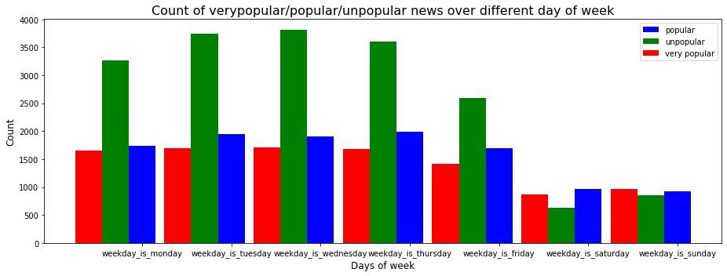

```python
columns_day=data.columns.values[31:38]
unpop_day = unpopular[columns_day].sum().values
pop_day = popular[columns_day].sum().values
verypop_day=very_popular[columns_day].sum().values
fig = plt.figure(figsize = (13,5))
plt.title("Count of verypopular/popular/unpopular news over different day of week", fontsize = 16)
plt.bar(np.arange(len(columns_day)), pop_day, width = 0.3, align="center", color = 'b', \
          label = "popular")
plt.bar(np.arange(len(columns_day)) - 0.3, unpop_day, width = 0.3, align = "center", color = 'g', \
          label = "unpopular")
plt.bar(np.arange(len(columns_day)) - 0.6, verypop_day, width = 0.3, align = "center", color = 'r', \
          label = "very popular")
plt.xticks(np.arange(len(columns_day)), columns_day)
plt.ylabel("Count", fontsize = 12)
plt.xlabel("Days of week", fontsize = 12)

plt.legend(loc = 'upper right')
plt.tight_layout()
plt.savefig("days.png")
plt.show()
```

### Count of verypopular/popular/unpopular news over different article category

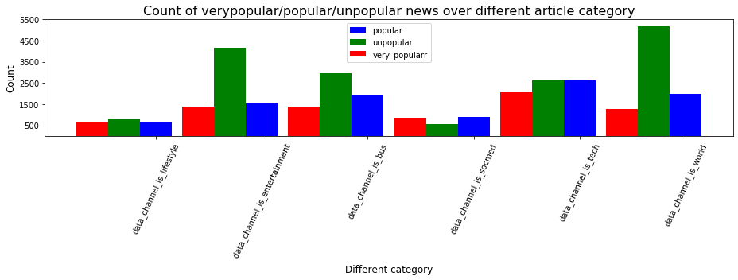

```python
columns_chan=data.columns.values[13:19]
unpop_chan = unpopular[columns_chan].sum().values
pop_chan = popular[columns_chan].sum().values
verypop_chan=very_popular[columns_chan].sum().values
fig = plt.figure(figsize = (13,5))
plt.title("Count of verypopular/popular/unpopular news over different article category", fontsize = 16)
plt.bar(np.arange(len(columns_chan)), pop_chan, width = 0.3, align="center", color = 'b', \
          label = "popular")
plt.bar(np.arange(len(columns_chan)) - 0.3, unpop_chan, width = 0.3, align = "center", color = 'g', \
          label = "unpopular")
plt.bar(np.arange(len(columns_chan)) - 0.6, verypop_chan, width = 0.3, align = "center", color = 'r', \
          label = "very_popularr")
plt.xticks(np.arange(len(columns_chan)), columns_chan)
plt.yticks(np.arange(500,6500,1000))
plt.xticks(rotation=65)

plt.ylabel("Count", fontsize = 12)
plt.xlabel("Different category", fontsize = 12)

plt.legend(loc = 'upper center')
plt.tight_layout()
plt.savefig("chan.png")
plt.show()
```

### Average num_imgs vs Average shares

**If there are more images then the article has high chance to be more popular**

```python
img_shares=data.groupby('Popularity')[['num_imgs','shares']].mean().reset_index()
```

```python
img_shares.rename(columns={'num_imgs':'avg_num_imgs','shares':'avg_shares'},inplace=True)
```

```python
img_shares
```

|  | Popularity | avg_num_imgs | avg_shares |
| --- | --- | --- | --- |
| 0 | 0 | 3.946944 | 909.489237 |
| 1 | 1 | 4.656158 | 1883.922974 |
| 2 | 2 | 5.524377 | 9686.254480 |

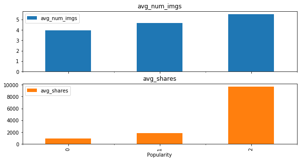

```python
img_shares.plot(x='Popularity',y=['avg_num_imgs','avg_shares'],kind='bar',subplots=True,figsize=(10,5))
plt.savefig('IMG vs Shares.png')
```

### Latent Dirichlet allocation

```python
LDA_00=data[data['LDA_00']>0.7]
l0=LDA_00.groupby('Popularity')['shares'].mean()
l0
```

```
Popularity
0     926.187626
1    1920.456398
2    8143.196347
Name: shares, dtype: float64
```

```python
LDA_01=data[data['LDA_01']>0.7]
l1=LDA_01.groupby('Popularity')['shares'].mean()
l1
```

```
Popularity
0      882.628276
1     1850.551876
2    10374.000000
Name: shares, dtype: float64
```

```python
LDA_02=data[data['LDA_02']>0.7]
l2=LDA_02.groupby('Popularity')['shares'].mean()
l2
```

```
Popularity
0     877.825452
1    1844.015444
2    7513.675214
Name: shares, dtype: float64
```

```python
LDA_03=data[data['LDA_03']>0.7]
l3=LDA_03.groupby('Popularity')['shares'].mean()
l3
```

```
Popularity
0      903.021352
1     1885.913313
2    12413.063584
Name: shares, dtype: float64
```

```python
LDA_04=data[data['LDA_04']>0.7]
l4=LDA_04.groupby('Popularity')['shares'].mean()
l4
```

```
Popularity
0     971.227072
1    1915.964025
2    7314.862915
Name: shares, dtype: float64
```

```python
LDA=pd.DataFrame({'Popularity':[0,1,2],'LDA_00':[l0[0],l0[1],l0[2]],'LDA_01':[l0[0],l0[1],l0[2]],'LDA_02':[l2[0],l2[1],l2[2]],'LDA_03':[l3[0],l3[1],l3[2]],'LDA_04':[l4[0],l4[1],l4[2]]})
```

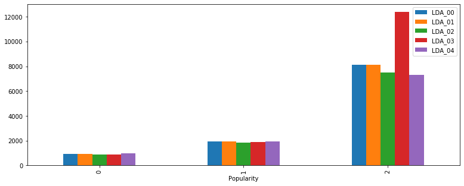

```python
LDA.plot(x='Popularity',y=['LDA_00','LDA_01','LDA_02','LDA_03','LDA_04'],kind='bar',figsize=(13,5))
plt.savefig('LDA.png')
```

## Creating independent and dependent variables for fitting the model

```python
x=data.drop(['Popularity'],axis=1)
x.drop(['url'],axis=1,inplace=True)
y=data['Popularity']
```

## Spliting the data for training and testing

```python
x_train, x_test, y_train, y_test = train_test_split(x,y, test_size=0.2,random_state=200)
```

## Model Building

### Logistic Regression

```python
logmodel=LogisticRegression()
logmodel.fit(x_train,y_train)
```

```
LogisticRegression(C=1.0, class_weight=None, dual=False, fit_intercept=True,
                   intercept_scaling=1, l1_ratio=None, max_iter=100,
                   multi_class='warn', n_jobs=None, penalty='l2',
                   random_state=None, solver='warn', tol=0.0001, verbose=0,
                   warm_start=False)
```

```python
predictions=logmodel.predict(x_test)
predictions
```

```
array([2, 0, 1, ..., 0, 0, 2], dtype=int64)
```

```python
from sklearn.metrics import confusion_matrix
```

```python
confusion_matrix(y_test,predictions)
```

```
array([[3591,   85,    1],
       [ 277, 1772,  228],
       [   0,   53, 1922]], dtype=int64)
```

```python
from sklearn.metrics import accuracy_score
accuracy_score(y_test,predictions)
```

```
0.9187791650901753
```

**The accuracy score for logistic regression is 91.8%**

### Random Forest Classifier

```python
clf=RandomForestClassifier(n_estimators=10,oob_score=True,n_jobs=-1,random_state=400)
clf.fit(x_train,y_train)
clf.oob_score_
```

```
0.9298439224341795
```

### Checking for best n_estimators

```python
for w in range(10,100,10):
    clf=RandomForestClassifier(n_estimators=w,oob_score=True,n_jobs=-1,random_state=400)
    clf.fit(x_train,y_train)
    oob=clf.oob_score_
    print('For n_estimators = '+str(w))
    print('OOB score is '+str(oob))
    print('************************')
```

```
For n_estimators = 10
OOB score is 0.9298439224341795
```

```
For n_estimators = 20
OOB score is 0.9725997162226075
For n_estimators = 30
OOB score is 0.9914866782279679
For n_estimators = 40
OOB score is 0.9952388459719376
For n_estimators = 50
OOB score is 0.9979189657890588
For n_estimators = 60
OOB score is 0.9989594828945294
For n_estimators = 70
OOB score is 0.99940091439382
For n_estimators = 80
OOB score is 0.9996531609648431
For n_estimators = 90
OOB score is 0.999684691786221
```

## At n_estimators=90 the OOB score is high

```python
clf=RandomForestClassifier(n_estimators=90,oob_score=True,n_jobs=-1,random_state=400)
clf.fit(x_train,y_train)
clf.oob_score_
```

```
0.999684691786221
```

```python
clf.feature_importances_
```

```
array([9.44418163e-03, 4.64041826e-03, 7.95701587e-03, 8.10304083e-03,
       6.15552572e-05, 8.10632136e-03, 6.77192884e-03, 3.87595444e-03,
       5.13883126e-03, 2.58025047e-03, 7.91730900e-03, 3.12517519e-03,
       4.61281879e-04, 3.08206175e-03, 7.98357139e-04, 1.96810898e-03,
       1.93560241e-03, 3.04284726e-03, 1.46587499e-03, 7.65732346e-03,
       8.50912478e-03, 5.00461942e-03, 1.70266811e-03, 8.32157798e-03,
       7.35831342e-03, 1.61959743e-02, 1.70391464e-02, 1.04032071e-02,
       8.09063487e-03, 1.06138047e-02, 8.60575776e-04, 8.43802311e-04,
       9.19956209e-04, 8.08846620e-04, 8.48852128e-04, 1.12499449e-03,
       9.17167034e-04, 3.98531151e-03, 8.76766785e-03, 8.72825528e-03,
       9.62978889e-03, 8.89901401e-03, 8.95874845e-03, 7.94479410e-03,
       7.49739718e-03, 7.72264297e-03, 7.00170691e-03, 6.15710536e-03,
       5.94037933e-03, 7.36654636e-03, 3.69972046e-03, 2.94546993e-03,
       7.11812825e-03, 4.37370627e-03, 4.12287024e-03, 4.01222005e-03,
       4.52463793e-03, 3.59159305e-03, 3.71698013e-03, 6.75598610e-01])
```

```python
feature_imp=pd.Series(clf.feature_importances_,index=x_train.columns).sort_values(ascending=False)
```

```python
feature_imp.head()
```

```
shares                        0.675599
kw_avg_avg                    0.017039
kw_max_avg                    0.016196
self_reference_avg_sharess    0.010614
self_reference_min_shares     0.010403
dtype: float64
```

### Using GridSearchCV for finding best estimator

```python
from sklearn.model_selection import GridSearchCV
rf=GridSearchCV(clf,param_grid={'max_depth':[3,5],'max_features':[5,6],'n_estimators':[85,90]})
rf.fit(x_train,y_train)
```

```
GridSearchCV(cv='warn', error_score='raise-deprecating',
             estimator=RandomForestClassifier(bootstrap=True, class_weight=None,
                                              criterion='gini', max_depth=None,
                                              max_features='auto',
                                              max_leaf_nodes=None,
                                              min_impurity_decrease=0.0,
                                              min_impurity_split=None,
                                              min_samples_leaf=1,
                                              min_samples_split=2,
                                              min_weight_fraction_leaf=0.0,
                                              n_estimators=90, n_jobs=-1,
                                              oob_score=True, random_state=400,
                                              verbose=0, warm_start=False),
             iid='warn', n_jobs=None,
             param_grid={'max_depth': [3, 5], 'max_features': [5, 6],
                         'n_estimators': [85, 90]},
             pre_dispatch='2*n_jobs', refit=True, return_train_score=False,
             scoring=None, verbose=0)
```

```python
rf.best_params_
```

```
{'max_depth': 5, 'max_features': 6, 'n_estimators': 85}
```

```python
rf.best_estimator_
```

```
RandomForestClassifier(bootstrap=True, class_weight=None, criterion='gini',
                       max_depth=5, max_features=6, max_leaf_nodes=None,
                       min_impurity_decrease=0.0, min_impurity_split=None,
                       min_samples_leaf=1, min_samples_split=2,
                       min_weight_fraction_leaf=0.0, n_estimators=85, n_jobs=-1,
                       oob_score=True, random_state=400, verbose=0,
                       warm_start=False)
```

```python
rf.best_score_
```

```
0.9389878606337695
```

```python
rf.score(x_test,y_test)
```

```
0.9417328793038214
```

**The accuracy score for Random Forest Classifier with best parameters is 94.17%**